# GIS for Ag: Raster Data for Crop Cover in Merced County

Case Study 2-2

Created by Madeline Brown

01/19/2022

University of California, Merced  
School of Engineering  
Spatial Analysis and Modeling (ENGR 180)

Key assignment steps are in RED

## Case Study Scenario

As a geospatial consultant for farmers in the Central Valley, you often work with client-provided datasets, including both raster and vector formats. Sometimes you inherit data from previous projects done by other consultants, such as statewide crop data from 2014. In this case study, you’ll have to practice rasterizing polygon data and do some summary statistics. You’ll also brush up on your ModelBuilder and Python skills, as you know the importance of replicability (and the importance of saving time by not having to start from scratch for all of your projects around the Valley!). It’s been a while since you’ve used ModelBuilder and Python, so by the time this project is over, you’ll remember the benefits of each, and where to use different data types for different needs.

In this half, you’ll use Python (within the Esri Package ArcPy) to compute, then compare acreages, between raster and vector formats.

## Introduction

Please read all of the instructions/narrative carefully! You may feel compelled to skim to find which elements you have to satisfy to get full credit. *If you skim, you may miss key sentences and you may end up doing more work than necessary!* Also, if you have questions, reread the steps leading up to your challenge. Your question is probably answered here!  
If text is in *italics*, it’s a tool or step within ArcGIS Pro.  
If text is underlined, it’s a file.

### Part 1: Compute Spatial Statistics with ArcPy

In this step, you will compare the areal statistics related to each crop type as depicted by the raster and vector representations of your crop dataset using ArcPy, the ArcGIS package for Python and a bit of Googling.

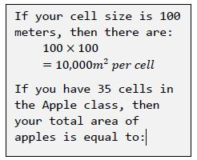

*1.3 Visualize your results*  
Produce a bar chart of the difference in areas of each class, between the vector representation and the raster representation (see Figure).  
• Save this chart as an image (by copying, or by taking a screenshot).  
Describe your submission in a few sentences. Describe what your chart is depicting and discuss your results.

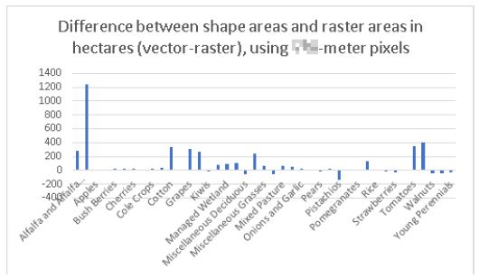

*1.4 Vector grid*  
In this step you will convert your raster land cover dataset back to vector polygons. You will again compute areal statistics and observe how they change once again.  
• Make sure that you have completed the steps in the previous section. You need to have the mcd_crops_[cellsize] file from the previous section.  
• Convert mcd_crops_[cellsize] raster layer to a polygon (vector) using *ModelBuilder* or ArcPy, whichever you prefer.  
o Save your output as ras_[cellsize]_crop_mcd  
Export a map of your result. Describe your submission in a few sentences. Discuss the differences between your original crop cover clip and the result of your vector-to-raster-to-vector conversion.

### Part 2: ModelBuilder versus ArcPy?

By now you’ve experienced the benefits of being able to see a process outlined visually through *ModelBuilder* and a brief intro to an ArcPy task. In previous versions of ArcGIS software, you could export a Model straight into Python. That was cool! For the time being, this isn’t possible because it isn’t a one-to-one conversion. Keep an eye out for it to be possible in the future. *ModelBuilder* benefits: great visuals, drag and drop approach. Python benefits: GIS external functionality.

### Part 3: Other- Vector Tiles

Are you rastered and vectored out yet? No? Good! One last topic to cover.  
GIS software are becoming increasingly web and app adapted. We use background imagery in our phones, tablets, drones, cars, and other technologies. Imagery used to be inherently raster (raster tiles), with levels of increasing detail as you zoom in. Raster tiles are large, and not scalable across different consumer technologies. Each time you zoom, the server-side has to re-render the imagery. The servers are working hard, they’re tired.  
Vector tiles [1,2] are vectorized data that take up less space on the server side and are rendered on the client side. This requires a stronger software, but the process is generally quicker. They can be adapted to fit whichever device they are on, such as a lineman’s tablet while they are inspecting transformers in the field.  
https://www.esri.com/training/catalog/5851736fd33f8b0b47b78e26/creating-vector-tiles-in-arcgis-pro/  
Answer: Provide one scenario for each: When would you want to use raster tiles? When would you want to use vector tiles?

## Submission

• 1.3: Bar chart image, description, and discussion.  
• 1.4: A map with accompanying description of the difference between the original crop cover layer and your vector to raster to vector conversion.  
• 3. Two scenarios (one each) for when you would want to use raster tiles or vector tiles.

## References

[1] MapBox, “Vector Tiles”. https://docs.mapbox.com/vector-tiles/reference/  
[2] Esri, ArcGIS Online Help, “Tile Layers”. https://doc.arcgis.com/en/arcgis-online/reference/tile-layers.html